# Final Midterm

Maria van Venrooy

## Societal Problem - Plastic Pollution

According to the Ocean Conservancy, "an endless flow of trash into the ocean will affecct the health of humans and wildlife alike as well as compromise the livelihoods that depend on a healthy ocean". The effects of plastic pollution are sever and far reaching, and learning more about the types of objects that end up in the waterways can help us better understand and combat the problem.

Source: https://oceanconservancy.org/blog/2016/08/22/the-problem-of-ocean-trash/

## Data set: Delaware Coastal Cleanup Results

```python
import pandas as pd
import numpy as np
import matplotlib.pyplot as plt

df = pd.read_csv("Delaware_Coastal_Cleanup_Results.csv")

df.head()
```

|  | County | Location Lat-Long | Cleanup Type | Cleanup Date | Cleanup Site | Adults | Children | People | Pounds | Miles | ... | Tampons/Tampon Applicators | Foam Pieces | Glass Pieces | Plastic Pieces | Clothing, Shoes | Shotgun Shells/Wadding | Light Bulbs/Tubes | Batteries | Cars/Car Parts | 55-Gallon Drums |
| --- | --- | --- | --- | --- | --- | --- | --- | --- | --- | --- | --- | --- | --- | --- | --- | --- | --- | --- | --- | --- | --- |
| 0 | Kent | (39.102739, -75.402356) | Beach | 09/20/2008 | Kitts Hummock | NaN | NaN | 45 | 1500.0 | 1.0 | ... | 15.0 | NaN | NaN | NaN | 11.0 | 70.0 | 1.0 | NaN | 4.0 | 3.0 |
| 1 | Kent | (39.085748, -75.421875) | Beach | 09/20/2008 | Ted Harvey WLA/ Ted Harvey Wildlife Area | NaN | NaN | 45 | 165.0 | 2.0 | ... | NaN | NaN | NaN | NaN | 4.0 | 33.0 | 2.0 | NaN | NaN | NaN |
| 2 | New Castle | (39.738765, -75.53939) | Beach | 09/20/2008 | E. 7th Street - Barbiarz Park | NaN | NaN | 18 | 180.0 | 1.0 | ... | NaN | NaN | NaN | NaN | 20.0 | NaN | 2.0 | 4.0 | 3.0 | NaN |
| 3 | New Castle | (39.664715, -75.557785) | Beach | 09/20/2008 | Battery Park | NaN | NaN | 51 | 892.0 | 0.5 | ... | 48.0 | NaN | NaN | NaN | 37.0 | 12.0 | 2.0 | 0.0 | 19.0 | 0.0 |
| 4 | New Castle | (39.504724, -75.580976) | Beach | 09/20/2008 | Augustine Beach Boat Ramp | NaN | NaN | 70 | 2200.0 | 1.0 | ... | 5.0 | NaN | NaN | NaN | 14.0 | NaN | NaN | NaN | 2.0 | NaN |

5 rows × 59 columns

```python
df["Cleanup Date"].value_counts()
```

```
09/16/2017    47
09/19/2015    46
09/17/2016    46
09/20/2014    45
09/14/2019    44
09/21/2013    42
09/22/2018    39
09/17/2011    37
09/15/2012    37
09/25/2010    35
09/19/2009    34
09/20/2008    30
09/15/2017     1
10/04/2008     1
06/18/2010     1
09/13/2014     1
09/12/2009     1
10/10/2012     1
09/24/2016     1
09/27/2015     1
09/18/2011     1
11/12/2008     1
09/13/2019     1
09/16/2016     1
Name: Cleanup Date, dtype: int64
```

From 2008 to 2019 there's a big cleanup day in September at lots of different locations, and a few other days scattered about at individual sites

## Question - Has the amount of smoking-related trash collected during DE cleanups decreased as smoking in Delaware has decreased?

If the amount of smoking-related trash has decreased as the rate of smoking decreased, this would show that changes to consumer habits (potentially) result in changes to the amount of trash found during cleanups.

Source: https://www.macrotrends.net/countries/USA/united-states/smoking-rate-statistics

### Number of Smoking-related Items over time

```python
allCols = list(df)
```

```python
#Smoking related: 'Cigarette Butts', 'Tobacco Packaging/Wrap', 'Cigar Tips', 'Cigarette Lighters'
smokingdf = df[['Cleanup Date','Cigarette Butts', 'Tobacco Packaging/Wrap', 'Cigar Tips', 'Cigarette Lighters']];
```

```python
listOfSmokingColumns = ['Cigarette Butts', 'Tobacco Packaging/Wrap', 'Cigar Tips', 'Cigarette Lighters'];
totalsmoke = df[listOfSmokingColumns].sum(axis=1);
smokingdf['total smoking items'] = totalsmoke;
```

```python
#Total amount of smoking related items found on cleanup day each day

smoke08 = smokingdf[smokingdf['Cleanup Date'] == '09/20/2008'];
smoke08 = smoke08['total smoking items'].sum();

smoke09 = smokingdf[smokingdf['Cleanup Date'] == '09/19/2009'];
smoke09 = smoke09['total smoking items'].sum();

smoke10 = smokingdf[smokingdf['Cleanup Date'] == '09/25/2010'];
smoke10 = smoke10['total smoking items'].sum();

smoke11 = smokingdf[smokingdf['Cleanup Date'] == '09/17/2011'];
smoke11 = smoke11['total smoking items'].sum();

smoke12 = smokingdf[smokingdf['Cleanup Date'] == '09/15/2012'];
smoke12 = smoke12['total smoking items'].sum();

smoke13 = smokingdf[smokingdf['Cleanup Date'] == '09/21/2013'];
smoke13 = smoke13['total smoking items'].sum();

smoke14 = smokingdf[smokingdf['Cleanup Date'] == '09/20/2014'];
smoke14 = smoke14['total smoking items'].sum();

smoke15 = smokingdf[smokingdf['Cleanup Date'] == '09/19/2015'];
smoke15 = smoke15['total smoking items'].sum();

smoke16 = smokingdf[smokingdf['Cleanup Date'] == '09/17/2016'];
smoke16 = smoke16['total smoking items'].sum();

smoke17 = smokingdf[smokingdf['Cleanup Date'] == '09/16/2017'];
smoke17 = smoke17['total smoking items'].sum();

smoke18 = smokingdf[smokingdf['Cleanup Date'] == '09/22/2018'];
smoke18 = smoke18['total smoking items'].sum();

smokeyeartotals = [smoke08,smoke09,smoke10,smoke11,smoke12,smoke13,smoke14,smoke15,smoke16,smoke17,smoke18]
smokeyears = [2008,2009,2010,2011,2012,2013,2014,2015,2016,2017,2018]

#df1 = pd.DataFrame(smokeyears);
#df2 = pd.DataFrame(smokeyeartotals)

smoketotalsdfunt = pd.DataFrame([smokeyears,smokeyeartotals]);
smoketotalsdf = smoketotalsdfunt.T;
smoketotalsdf.columns = ['Year', 'Number Of Smoking Items']
```

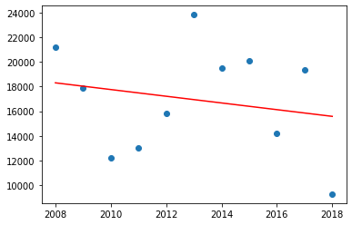

```python
%matplotlib inline

x = smoketotalsdf['Year'];
y = smoketotalsdf['Number Of Smoking Items']

model = np.polyfit(x,y,1)

predict = np.poly1d(model)
x_lin_reg = range(2008,2019)
y_lin_reg = predict(x_lin_reg)
plt.scatter(x,y);
plt.plot(x_lin_reg, y_lin_reg, c = 'r')


#Source referenced:
#https://data36.com/linear-regression-in-python-numpy-polyfit/
```

```python
import sklearn.metrics as metrics
yhat = [predict(2008),predict(2009),predict(2010),predict(2011),predict(2012),predict(2013),predict(2014),predict(2015),predict(2016),predict(2017),predict(2018)]

mae = metrics.mean_absolute_error(y,yhat);
print("Mean absolute error: ",mae);

r2 = metrics.r2_score(y,yhat);
print("R-squared: ", r2);
```

```
Mean absolute error:  3603.8082644627957
R-squared:  0.04185325832338582
```

R-squared is 4%, so only 4% of the data fits in the model, so we can't draw any conclusions from this analysis. There is no apparent trend in the number of smoking-related items.

Now, let's see if there is a trend in the percent of items that are smoking related.

### Percentage of Smoking-related Items over time

```python
alltrashcols = [
 'Cigarette Butts',
 'Food Wrappers',
 'Take Out/Away Containers (Plastic)',
 'Take Out/Away Containers (Foam)',
 'Bottle Caps (Plastic)',
 'Bottle Caps (Metal)',
 'Lids (Plastic)',
 'Straws, Stirrers',
 'Forks, Knives, Spoons',
 'Beverage Bottles (Plastic)',
 'Beverage Bottles (Glass)',
 'Beverage Cans',
 'Grocery Bags (Plastic)',
 'Other Plastic Bags',
 'Paper Bags',
 'Cups, Plates (Paper)',
 'Cups, Plates (Plastic)',
 'Cups, Plates (Foam)',
 'Fishing Buoys, Pots & Traps',
 'Fishing Net & Pieces',
 'Fishing Line',
 'Rope',
 '6-Pack Holders',
 'Other Plastic/Foam Packaging',
 'Other Plastic Bottles',
 'Strapping Bands',
 'Tobacco Packaging/Wrap',
 'Appliances',
 'Balloons',
 'Cigar Tips',
 'Cigarette Lighters',
 'Construction Materials',
 'Fireworks',
 'Tires',
 'Toys',
 'Condoms',
 'Diapers',
 'Syringes',
 'Tampons/Tampon Applicators',
 'Foam Pieces',
 'Glass Pieces',
 'Plastic Pieces',
 'Clothing, Shoes',
 'Shotgun Shells/Wadding',
 'Light Bulbs/Tubes',
 'Batteries',
 'Cars/Car Parts',
 '55-Gallon Drums'];
```

```python
smokebyperc = df;

#alltrash08df = smokebyperc.loc[smokebyperc['Cleanup Date'] == '09/20/2008']
alltrash =  smokebyperc[alltrashcols].sum(axis=1);
```

```python
smokebyperc['all trash num'] = alltrash;

smokebyperc

alltrash08 = smokebyperc[smokebyperc['Cleanup Date'] == '09/20/2008'];
alltrash08 = alltrash08['all trash num'].sum();

alltrash09 = smokebyperc[smokebyperc['Cleanup Date'] == '09/19/2009'];
alltrash09 = alltrash09['all trash num'].sum();

alltrash10 = smokebyperc[smokebyperc['Cleanup Date'] == '09/25/2010'];
alltrash10 = alltrash10['all trash num'].sum();

alltrash11 = smokebyperc[smokebyperc['Cleanup Date'] == '09/17/2011'];
alltrash11 = alltrash11['all trash num'].sum();

alltrash12 = smokebyperc[smokebyperc['Cleanup Date'] == '09/15/2012'];
alltrash12 = alltrash12['all trash num'].sum();

alltrash13 = smokebyperc[smokebyperc['Cleanup Date'] == '09/21/2013'];
alltrash13 = alltrash13['all trash num'].sum();

alltrash14 = smokebyperc[smokebyperc['Cleanup Date'] == '09/20/2014'];
alltrash14 = alltrash14['all trash num'].sum();

alltrash15 = smokebyperc[smokebyperc['Cleanup Date'] == '09/19/2015'];
alltrash15 = alltrash15['all trash num'].sum();

alltrash16 = smokebyperc[smokebyperc['Cleanup Date'] == '09/17/2016'];
alltrash16 = alltrash16['all trash num'].sum();

alltrash17 = smokebyperc[smokebyperc['Cleanup Date'] == '09/16/2017'];
alltrash17 = alltrash17['all trash num'].sum();

alltrash18 = smokebyperc[smokebyperc['Cleanup Date'] == '09/22/2018'];
alltrash18 = alltrash18['all trash num'].sum();


alltrashyeartotals = [alltrash08,alltrash09,alltrash10,alltrash11,alltrash12,alltrash13,alltrash14,alltrash15,alltrash16,alltrash17,alltrash18]
```

[output not shown]

```python
smokeaspercdf = smoketotalsdf;
smokeaspercdf['Total trash items'] = alltrashyeartotals;

smokeasperccol = smokeaspercdf['Number Of Smoking Items'] / smokeaspercdf['Total trash items'] * 100
smokeaspercdf['Percent items smoke related'] = smokeasperccol;
```

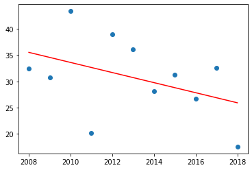

```python
%matplotlib inline

x = smokeaspercdf['Year'];
y = smokeaspercdf['Percent items smoke related']

model = np.polyfit(x,y,1)

predict = np.poly1d(model)
x_lin_reg = range(2008,2019)
y_lin_reg = predict(x_lin_reg)
plt.scatter(x,y);
plt.plot(x_lin_reg, y_lin_reg, c = 'r')


#Source referenced:
#https://data36.com/linear-regression-in-python-numpy-polyfit/
```

```python
start = 2008;
predict(start)
```

```
35.53458868594521
```

```python
end = 2018;
predict(end)
```

```
25.939870021286197
```

The regression model shows a decrease in percentage of smoking-related trash from ~35% of items in 2008 to ~26% of items in 2018

```python
import sklearn.metrics as metrics
yhat = [predict(2008),predict(2009),predict(2010),predict(2011),predict(2012),predict(2013),predict(2014),predict(2015),predict(2016),predict(2017),predict(2018)]

mae = metrics.mean_absolute_error(y,yhat);
print("Mean absolute error: ",mae);

r2 = metrics.r2_score(y,yhat);
print("R-squared: ", r2);
```

```
Mean absolute error:  5.554562804179552
R-squared:  0.17728825650900615
```

R-squared is ~18%, so we have very high variance, so the fit of the model is poor. Given the high variance of the model, it would not be wise to draw any conclusions from this data. There is no clear trend in the percentage of smoking-related items over time

Source on r2 value: https://www.knowledgehut.com/blog/data-science/interpret-r-squared-and-goodness-fit-regression-analysis

## Single Use Plastics

### Question: Has the amount of single use plastic recovered at cleanup events decreased over time?

I had expected the amount of smoking-related trash to decrease as the rate of smoking decreased, and I planned to use that info to infer that if we reduce our use of single use plastic, we will see less single-use plastic trash recovered at clean ups. However, my findings are still valuable, and unexpected results do not equal failure. The science continues...

Now let's look at single use plastics! What is a single-use plastic? It's an item made of plastic which is meant to be disposed of right after use (NRDC). This includes plastic water bottles, plastic grocery bags, plastic takeout containers, plastic packaging for food products, and more.

According to earthday.org, "Single-use-plastics frequently do not make it to a landfill or are recycled. A full 32% of the 78 million tons of plastic packaging produced annually is left to flow into our oceans; the equivalent of pouring one garbage truck fill of plastic into the ocean every minute" (earthday.org)

Why are single use plastics a problem? Because plastic cannot biodegrade; instead it breaks up into lots of tiny pieces called microplastics. According to Nature's Path, " It can take up to thousands of years for [plastic] to decompose. In the meantime, it contaminates our soil and water. The toxic chemicals used to manufacture plastic get transfered to animal tissue, eventually entering the human food chain... and can damage nervous systems, lungs, and reproductive organs"

Nature's Way also points out that plastic also negatively impacts sea creatures, "Plastic items like bags and straws choke wildlife and block animals' stomachs"

I am focusing on single use plastics here because they make up such a large portion of all plastics, and they are (by definition) super wasteful. There has been a recent push to ban different single use plastics (See Delaware 2021 plastic bag ban from delaware.gov source below). It is important to get a clear picture of how much single use plastic ends up on our beaches, as this information could help drive more policies like the plastic bag ban.

Sources:

- https://www.nrdc.org/stories/single-use-plastics-101#what
- https://www.earthday.org/fact-sheet-single-use-plastics/
- https://www.naturespath.com/en-us/blog/single-use-plastics-bad-can/
- https://news.delaware.gov/2020/12/01/plastic-carryout-bag-ban-effective-on-jan-1-2021/

Ethics Note: my analysis could be used to assert that individuals are responsible for pollution, rather than corporations. Personally I think that personal actions like using a reusable waterbottle and buying things used rather than new are important and valuable, but placing responsibility exclusively on consumers is definitely problematic.

```python
singleUsePlastics = [
                        'Cigarette Butts',
                     'Food Wrappers',
                     'Take Out/Away Containers (Plastic)',
                     'Take Out/Away Containers (Foam)',
                     'Bottle Caps (Plastic)',
                     'Lids (Plastic)',
                     'Straws, Stirrers',
                     'Forks, Knives, Spoons',
                     'Beverage Bottles (Plastic)',
                     'Grocery Bags (Plastic)',
                     'Other Plastic Bags',
                     'Cups, Plates (Plastic)',
                     'Cups, Plates (Foam)',
                     'Other Plastic Bottles',
                     'Balloons',
                     'Cigar Tips',
                     'Tampons/Tampon Applicators'
                      ]

singleUsePlasticswDate = [ 'Cleanup Date',
                        'Cigarette Butts',
                     'Food Wrappers',
                     'Take Out/Away Containers (Plastic)',
                     'Take Out/Away Containers (Foam)',
                     'Bottle Caps (Plastic)',
                     'Lids (Plastic)',
                     'Straws, Stirrers',
                     'Forks, Knives, Spoons',
                     'Beverage Bottles (Plastic)',
                     'Grocery Bags (Plastic)',
                     'Other Plastic Bags',
                     'Cups, Plates (Plastic)',
                     'Cups, Plates (Foam)',
                     'Other Plastic Bottles',
                     'Balloons',
                     'Cigar Tips',
                     'Tampons/Tampon Applicators'
                      ]

#Reference to see if some items (cigarette butts, food wrappers) are considered single use:
# https://www.naturespath.com/en-us/blog/single-use-plastics-bad-can/
```

#### Ethics Note:

Condoms are listed as their own category for the cleanups, and technically they are a single-use plastic, but there are certainly some ethical concerns with discouraging the use of condoms based on them being single use. I will be excluding condoms from my list of single use plastics, both due to ethical concerns and the fact that many condoms are made from plant-based latex (https://en.wikipedia.org/wiki/Latex#Personal_and_healthcare_products)

```python
sudf = df[singleUsePlasticswDate];
totalsingleuse = df[singleUsePlastics].sum(axis=1);

sudf['single use total'] = totalsingleuse;
```

```python
finalsingleusedf = smokeaspercdf[['Year', 'Total trash items']];

singleuse08 = sudf[sudf['Cleanup Date'] == '09/20/2008'];
singleuse08 = singleuse08['single use total'].sum();

singleuse09 = sudf[sudf['Cleanup Date'] == '09/19/2009'];
singleuse09 = singleuse09['single use total'].sum();

singleuse10 = sudf[sudf['Cleanup Date'] == '09/25/2010'];
singleuse10 = singleuse10['single use total'].sum();

singleuse11 = sudf[sudf['Cleanup Date'] == '09/17/2011'];
singleuse11 = singleuse11['single use total'].sum();

singleuse12 = sudf[sudf['Cleanup Date'] == '09/15/2012'];
singleuse12 = singleuse12['single use total'].sum();

singleuse13 = sudf[sudf['Cleanup Date'] == '09/21/2013'];
singleuse13 = singleuse13['single use total'].sum();

singleuse14 = sudf[sudf['Cleanup Date'] == '09/20/2014'];
singleuse14 = singleuse14['single use total'].sum();

singleuse15 = sudf[sudf['Cleanup Date'] == '09/19/2015'];
singleuse15 = singleuse15['single use total'].sum();

singleuse16 = sudf[sudf['Cleanup Date'] == '09/17/2016'];
singleuse16 = singleuse16['single use total'].sum();

singleuse17 = sudf[sudf['Cleanup Date'] == '09/16/2017'];
singleuse17 = singleuse17['single use total'].sum();

singleuse18 = sudf[sudf['Cleanup Date'] == '09/22/2018'];
singleuse18 = singleuse18['single use total'].sum();

singleuseyeartotals = [singleuse08,singleuse09,singleuse10,singleuse11,singleuse12,singleuse13,singleuse14,singleuse15,singleuse16,singleuse17,singleuse18]

finalsingleusedf['Num Single Use'] = singleuseyeartotals


SupAsPercCol = finalsingleusedf['Num Single Use'] / finalsingleusedf['Total trash items'] * 100
finalsingleusedf['Percent items Single Use'] = SupAsPercCol;
```

### Single Use Plastics by Raw Number

```python
sum(singleuseyeartotals)
```

```
432969.0
```

The total number of single-use plastics recovered at the yearly clean up day is 432,969

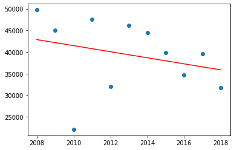

```python
%matplotlib inline

xsunp = finalsingleusedf['Year'];
ysunp = finalsingleusedf['Num Single Use']

modelsunp = np.polyfit(xsunp,ysunp,1)

predictsunp = np.poly1d(modelsunp)
x_lin_reg_sunp = range(2008,2019)
y_lin_reg_sunp = predictsunp(x_lin_reg_sunp)
plt.scatter(xsunp,ysunp);
plt.plot(x_lin_reg_sunp, y_lin_reg_sunp, c = 'r')
```

```python
import sklearn.metrics as metrics
yhatsunp = [predictsunp(2008),predictsunp(2009),predictsunp(2010),predictsunp(2011),predictsunp(2012),predictsunp(2013),predictsunp(2014),predictsunp(2015),predictsunp(2016),predictsunp(2017),predictsunp(2018)]

maesunp = metrics.mean_absolute_error(ysunp,yhatsunp);
print("Mean absolute error: ",maesunp);

r2sunp = metrics.r2_score(ysunp,yhatsunp);
print("R-squared: ", r2sunp);
```

```
Mean absolute error:  6194.667768595211
R-squared:  0.07600427414586663
```

### Single Use Plastics by Percentage of Items

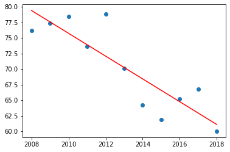

```python
%matplotlib inline

xsu = finalsingleusedf['Year'];
ysu = finalsingleusedf['Percent items Single Use']

modelsu = np.polyfit(xsu,ysu,1)

predictsu = np.poly1d(modelsu)
x_lin_reg_su = range(2008,2019)
y_lin_reg_su = predictsu(x_lin_reg_su)
plt.scatter(xsu,ysu);
plt.plot(x_lin_reg_su, y_lin_reg_su, c = 'r')


#Source referenced:
#https://data36.com/linear-regression-in-python-numpy-polyfit/
```

```python
import sklearn.metrics as metrics
yhatsu = [predictsu(2008),predictsu(2009),predictsu(2010),predictsu(2011),predictsu(2012),predictsu(2013),predictsu(2014),predictsu(2015),predictsu(2016),predictsu(2017),predictsu(2018)]

maesu = metrics.mean_absolute_error(ysu,yhatsu);
print("Mean absolute error: ",maesu);

r2su = metrics.r2_score(ysu,yhatsu);
print("R-squared: ", r2su);
```

```
Mean absolute error:  2.4978298624459643
R-squared:  0.7557168225458155
```

R-squared of 75% means that most of the data fits the model, showing a strong trend of the percentage of single use plastics found at clean ups decreasing.

## Conclusion

Additionally, the fact that over 400,000 pieces of single use plastic have been recovered from just 11 individual cleanup days is disturbing, but hopefully shows people that using single use plastics has serious implications. Ideally, this information could be used to support more anti-single-use-plastic legislation.

## Important Considerations:

"When a measure becomes a target, it ceases to be a good measure" (https://en.wikipedia.org/wiki/Goodhart%27s_law)

It is important to note that the goal of a cleanup is to remove as much trash from the environment as possible, so high numbers of items recovered is a successful cleanup. We should not aim for no plastic being recovered at a cleanup - that could mean no clean ups altogether, and even more plastic in the waterways and surrounding areas.